# HW1

Xinrui Zhang UID:605231530

## Problem 3

**pre-processing**

```r
## pre-processing

data_max<-read.csv('USW00023174_TMAX_clean.csv',header = T)
value_max<-data_max$value

data_min <- read.csv('USW00023174_TMIN_clean.csv',header = T)
value_min <- data_min$value
Nyear<-floor(length(value_max)/365)-1
Nyear_full <- floor(length(value_max)/365)-1
DAYofYEAR <-c(1:365)
date_1<-as.Date('1944-8-1')
date_2<-as.Date('1944-12-31')
interval1 <- as.integer(difftime(date_2,date_1,units='days'))
DAY1944 <- c((365-interval1):365)
day_ordered<-c(DAY1944,rep(DAYofYEAR,Nyear_full))
day_left <- length(value_max)-length(day_ordered) # day has the same order as the data
day_ordered <- c(day_ordered,c(1:day_left))

## separate a year into 12 month
daySEPseason <- day_ordered #day seperated by month
daySEPseason[(daySEPseason>=1 & daySEPseason<=59) |
              (daySEPseason>=335 & daySEPseason<=365)] <-1 #DJF
daySEPseason[(daySEPseason>=60 & daySEPseason<=151)] <-2 #MAM
daySEPseason[daySEPseason>=152 & daySEPseason<=243] <-3 #JJA
daySEPseason[daySEPseason>=244 & daySEPseason<=334] <-4 #SON

## construct a data frame to process missing values
seasonDATA_frame <- data.frame(daySEPseason,value_max)
seasonDATA_frameMIN <- data.frame(daySEPseason,value_min)
seasonDATA_frame <- seasonDATA_frame[seasonDATA_frame$value_max!=-999.9,]
seasonDATA_frameMIN <- seasonDATA_frameMIN[seasonDATA_frameMIN$value_min!=-999.9,]

## divide data into 4 seasons
DJF_max <- seasonDATA_frame$value_max[seasonDATA_frame$daySEPseason==1]
MAM_max <- seasonDATA_frame$value_max[seasonDATA_frame$daySEPseason==2]
JJA_max <- seasonDATA_frame$value_max[seasonDATA_frame$daySEPseason==3]
SON_max <- seasonDATA_frame$value_max[seasonDATA_frame$daySEPseason==4]

DJF_min <- seasonDATA_frameMIN$value_min[seasonDATA_frameMIN$daySEPseason==1]
MAM_min <- seasonDATA_frameMIN$value_min[seasonDATA_frameMIN$daySEPseason==2]
JJA_min <- seasonDATA_frameMIN$value_min[seasonDATA_frameMIN$daySEPseason==3]
SON_min <- seasonDATA_frameMIN$value_min[seasonDATA_frameMIN$daySEPseason==4]
```

### a)

**maximum**

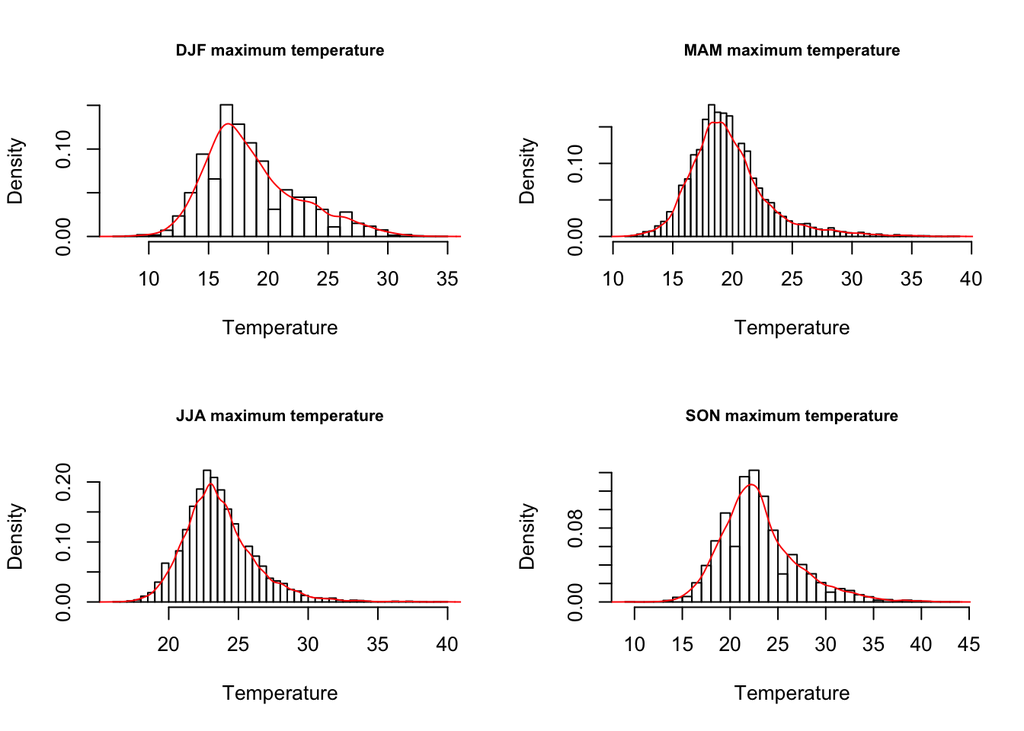

```r
## maximum temperature
Opar <- par(no.readonly = T) # store the original settings
par(mfrow=c(2,2),ann=F)
hist(DJF_max,freq = F,xlab = 'Temperature',
     main='DJF maximum temperature',cex.main=0.8,breaks = 'Scott')#using Scott's method to determine bin width
lines(density(DJF_max,bw='nrd'),col='red')
hist(MAM_max,freq = F,xlab = 'Temperature',
     main='MAM maximum temperature',cex.main=0.8,breaks = 'Scott')
lines(density(MAM_max,bw='nrd'),col='red')
hist(JJA_max,freq = F,xlab = 'Temperature',
     main='JJA maximum temperature',cex.main=0.8,breaks = 'Scott')
lines(density(JJA_max,bw='nrd'),col='red')
hist(SON_max,freq = F,xlab = 'Temperature',
     main='SON maximum temperature',cex.main=0.8,breaks = 'Scott')
lines(density(SON_max,bw='nrd'),col='red')
```

```r
par(Opar)
```

**minimum**

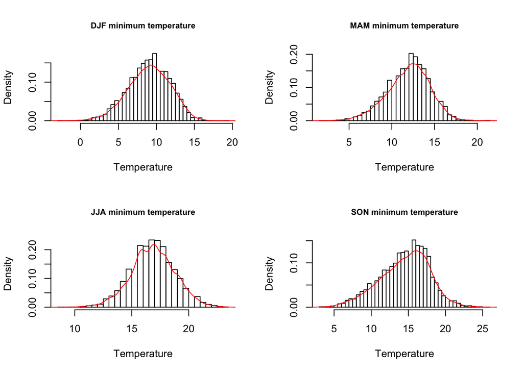

```r
## minimum temperature
Opar <- par(no.readonly = T) # store the original settings
par(mfrow=c(2,2),ann=F)
hist(DJF_min,freq = F,xlab = 'Temperature',
     main='DJF minimum temperature',cex.main=0.8,breaks = 'Scott')
lines(density(DJF_min,bw='nrd'),col='red')
hist(MAM_min,freq = F,xlab = 'Temperature',
     main='MAM minimum temperature',cex.main=0.8,breaks = 'Scott')
lines(density(MAM_min,bw='nrd'),col='red')
hist(JJA_min,freq = F,xlab = 'Temperature',
     main='JJA minimum temperature',cex.main=0.8,breaks = 'Scott')
lines(density(JJA_min,bw='nrd'),col='red')
hist(SON_min,freq = F,xlab = 'Temperature',
     main='SON minimum temperature',cex.main=0.8,breaks = 'Scott')
lines(density(SON_min,bw='nrd'),col='red')#using Scott's method to determine bin width
```

```r
par(Opar)
```

**bonus (bin size=0.5)**

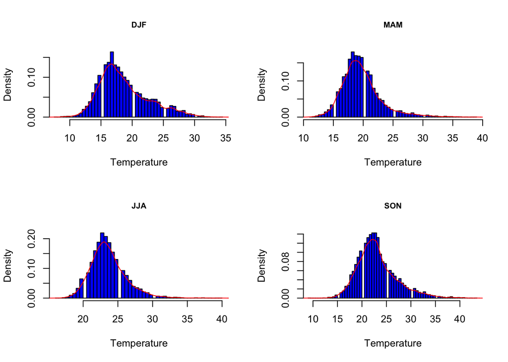

```r
## bonus
Opar <- par(no.readonly = T) # store the original settings
par(mfrow=c(2,2),ann=F)
hist(DJF_max,freq = F,xlab = 'Temperature',
     main='DJF',cex.main=0.8,breaks = 2*(max(DJF_max)-min(DJF_max)),xlim = c(min(DJF_max),max(DJF_max)),
     col='blue')
lines(density(DJF_max,bw=0.5),col='red')
hist(MAM_max,freq = F,xlab = 'Temperature',
     main='MAM',cex.main=0.8,breaks = 2*(max(MAM_max)-min(MAM_max)),xlim = c(min(MAM_max),max(MAM_max)),
     col='blue')
lines(density(MAM_max,bw=0.5),col='red')
hist(JJA_max,freq = F,xlab = 'Temperature',
     main='JJA',cex.main=0.8,breaks = 2*(max(JJA_max)-min(JJA_max)),xlim = c(min(JJA_max),max(JJA_max)),
     col='blue')
lines(density(JJA_max,bw=0.5),col='red')
hist(SON_max,freq = F,xlab = 'Temperature',
     main='SON',cex.main=0.8,breaks = 2*(max(SON_max)-min(SON_max)),xlim = c(min(SON_max),max(SON_max)),
     col='blue')
lines(density(SON_max,bw=0.5),col='red')
```

```r
par(Opar)
```

**The hitograms present some blanks when `bin width` changed to `0.5`, since the whole range is devided more accurately into smaller sub-ranges, chance exists that no value hit exactly into that certain smaller range.Given above, to correctly chose bin size is important.**

### b)

```r
SUMTx <- 0
for (i in (1:length(DJF_max))){
  SUMTx<-SUMTx + DJF_max[i]
}
MEANTx <- SUMTx/length(DJF_max)
print(paste('mean for winter maximum temperature is ', MEANTx)) #mean
```

```
## [1] "mean for winter maximum temperature is  18.6640282367077"
```

```r
SorwinterTx <- sort(DJF_max) # sorted winter data
MEDIANTx <- (sort(DJF_max)[length(DJF_max)/2]) #mediant
print(paste('mediant for winter maximum temperature is ', MEDIANTx))
```

```
## [1] "mediant for winter maximum temperature is  17.8"
```

```r
VARIANCE <- 0
MeanAbDev <- 0 # mean absolute deviation
m3 <- 0
m4 <- 0
for (i in (1:length(DJF_max))){
  VARIANCE <- VARIANCE + (DJF_max[i]-MEANTx)^2
  MeanAbDev <- MeanAbDev + abs(DJF_max[i]-MEANTx)
  m3 <- m3 + (DJF_max[i]-MEANTx)^3
  m4 <- m4 + (DJF_max[i]-MEANTx)^4
}
SDTx <- sqrt(VARIANCE/length(DJF_max)) #standard deviation
MeanAbDev <- MeanAbDev/length(DJF_max) # mean absolute deviation
m3 <- m3/length(DJF_max)
m4 <- m4/length(DJF_max)
SKEWNESS <- m3/(SDTx^3)
KURTOSIS <- m4/(SDTx^4)
print(paste('standard deviation for winter maximum temperature is ', SDTx))
```

```
## [1] "standard deviation for winter maximum temperature is  3.93700078513342"
```

```r
print(paste('skewness for winter maximum temperature is ', SKEWNESS))
```

```
## [1] "skewness for winter maximum temperature is  0.764472634350986"
```

```r
print(paste('kurtosis for winter maximum temperature is ', KURTOSIS))
```

```
## [1] "kurtosis for winter maximum temperature is  3.27273020623528"
```

```r
print(paste('mean absolute deviation for winter maximum temperature is ', MeanAbDev))
```

```
## [1] "mean absolute deviation for winter maximum temperature is  3.12353053863381"
```

```r
Q25Tx <- SorwinterTx[floor(0.25*length(DJF_max))]
Q75Tx <- SorwinterTx[floor(0.75*length(DJF_max))]
print(paste('25 quantile for winter maximum temperature is ', Q25Tx))
```

```
## [1] "25 quantile for winter maximum temperature is  16.1"
```

```r
print(paste('75 quantile for winter maximum temperature is ', Q75Tx))
```

```
## [1] "75 quantile for winter maximum temperature is  21.1"
```

## problem 4

### a) to determine the parameter lambda

**Since the original data has a positive skew, the lamda should smaller than 1. First use a sequence of assumed lambda to caculate some evaluation indicators**

```
## [1] "when lambda = -0.5  log-likelyhood is 16031.2045714758"
## [1] "when lambda = -0.5  d statistic is 0.0592560979610667"
```

```
## [1] "when lambda = -0.4  log-likelyhood is 13315.724072686"
## [1] "when lambda = -0.4  d statistic is 0.0667771512409756"
```

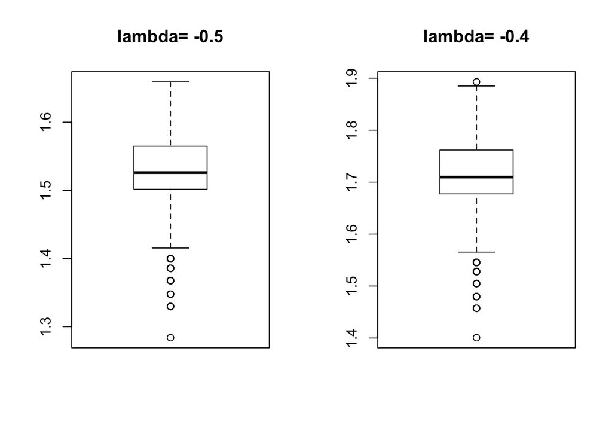

```
## [1] "when lambda = -0.3  log-likelyhood is 10691.2726716122"
## [1] "when lambda = -0.3  d statistic is 0.0742909670717094"
```

```
## [1] "when lambda = -0.2  log-likelyhood is 8169.51599617313"
## [1] "when lambda = -0.2  d statistic is 0.081800848150082"
```

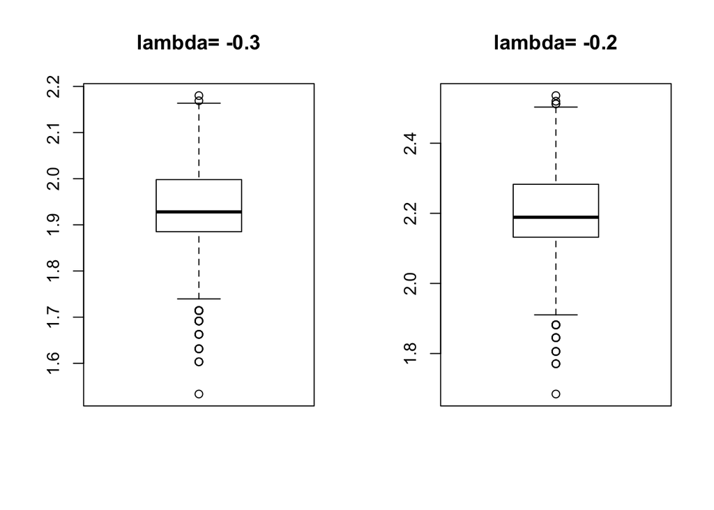

```
## [1] "when lambda = -0.1  log-likelyhood is 5763.00692618766"
## [1] "when lambda = -0.1  d statistic is 0.0893100817867702"
```

```r
Opar <- par(no.readonly = T) # store the original settings
par(mfrow=c(1,2),ann=F)
LAMBDA <- seq(-0.5,-0.1,by=0.1)
for (i in LAMBDA){
  BCtry <- (DJF_max^i-1)/i
  Llambda <- -length(DJF_max)/2*log((sd(BCtry))^2)+(i-1)*sum(log(BCtry))
  print(paste('when lambda =',i,' log-likelyhood is',Llambda))
  dlambda <- abs(mean(BCtry)-
                   median(BCtry))/(as.numeric(quantile(BCtry,na.rm = T)[4]-
                   quantile(BCtry,na.rm = T)[2]))
  print(paste('when lambda =',i,' d statistic is',dlambda))
  #quantile[2] means 25%
  boxplot(BCtry,main=paste('lambda=',i))
}
```

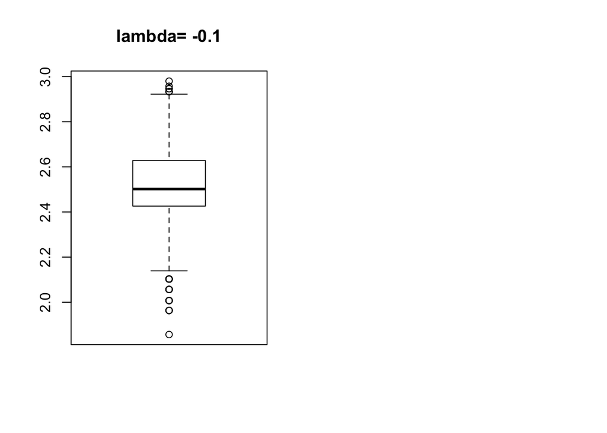

```r
par(Opar)
```

```
## [1] "when lambda = 0.1  log-likelyhood is 1349.57214441694"
## [1] "when lambda = 0.1  d statistic is 0.104339703549305"
```

```
## [1] "when lambda = 0.2  log-likelyhood is -629.137885884047"
## [1] "when lambda = 0.2  d statistic is 0.111866625850558"
```

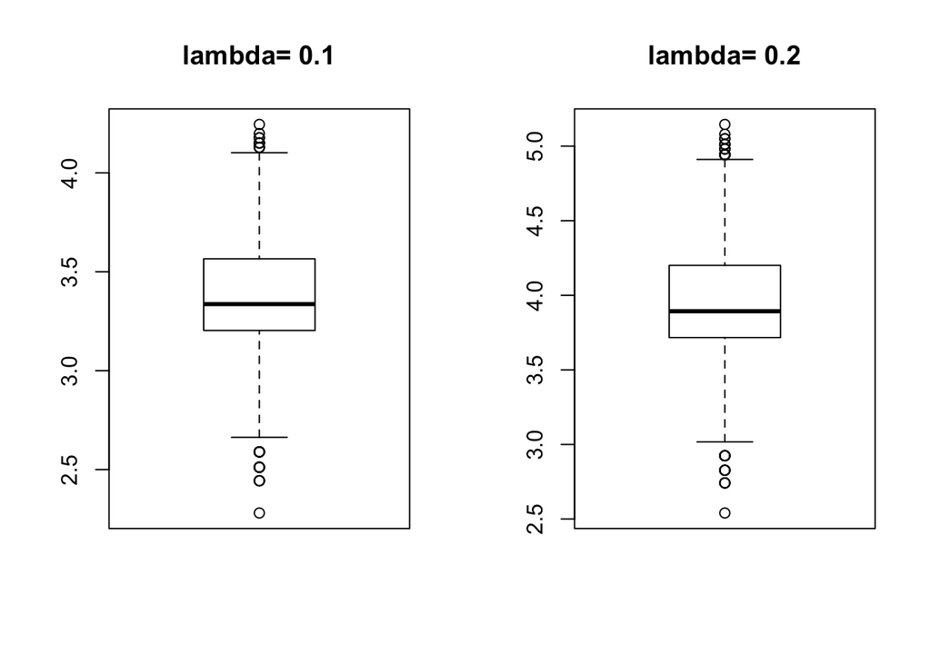

```
## [1] "when lambda = 0.3  log-likelyhood is -2436.56820046423"
## [1] "when lambda = 0.3  d statistic is 0.119405976891443"
```

```
## [1] "when lambda = 0.4  log-likelyhood is -4058.23096404614"
## [1] "when lambda = 0.4  d statistic is 0.126961027043404"
```

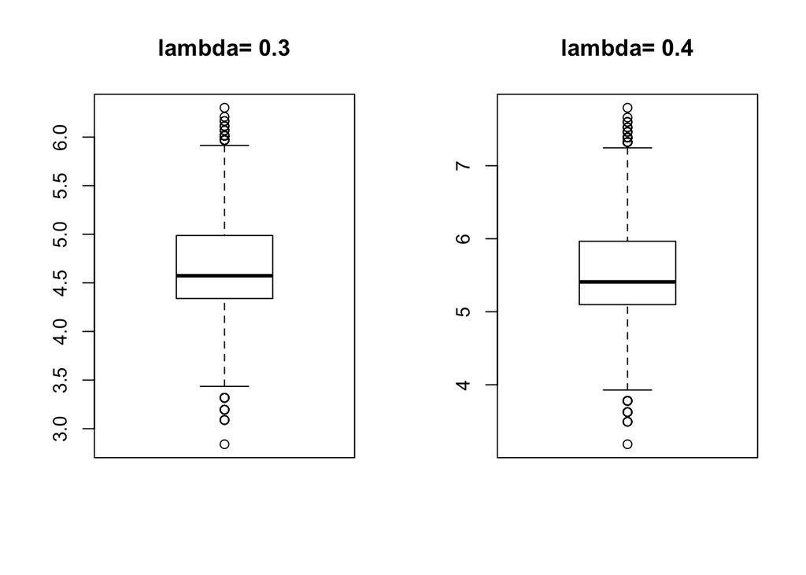

```
## [1] "when lambda = 0.5  log-likelyhood is -5479.86031514857"
## [1] "when lambda = 0.5  d statistic is 0.134535054844223"
```

```r
Opar <- par(no.readonly = T) # store the original settings
par(mfrow=c(1,2),ann=F)
LAMBDA <- seq(0.1,0.5,by=0.1)
for (i in LAMBDA){
  BCtry <- (DJF_max^i-1)/i
  Llambda <- -length(DJF_max)/2*log((sd(BCtry))^2)+(i-1)*sum(log(BCtry))
  print(paste('when lambda =',i,' log-likelyhood is',Llambda))
  dlambda <- abs(mean(BCtry)-
                   median(BCtry))/(as.numeric(quantile(BCtry,na.rm = T)[4]-
                   quantile(BCtry,na.rm = T)[2]))
  print(paste('when lambda =',i,' d statistic is',dlambda))
  #quantile[2] means 25%
  boxplot(BCtry,main=paste('lambda=',i))
}
```

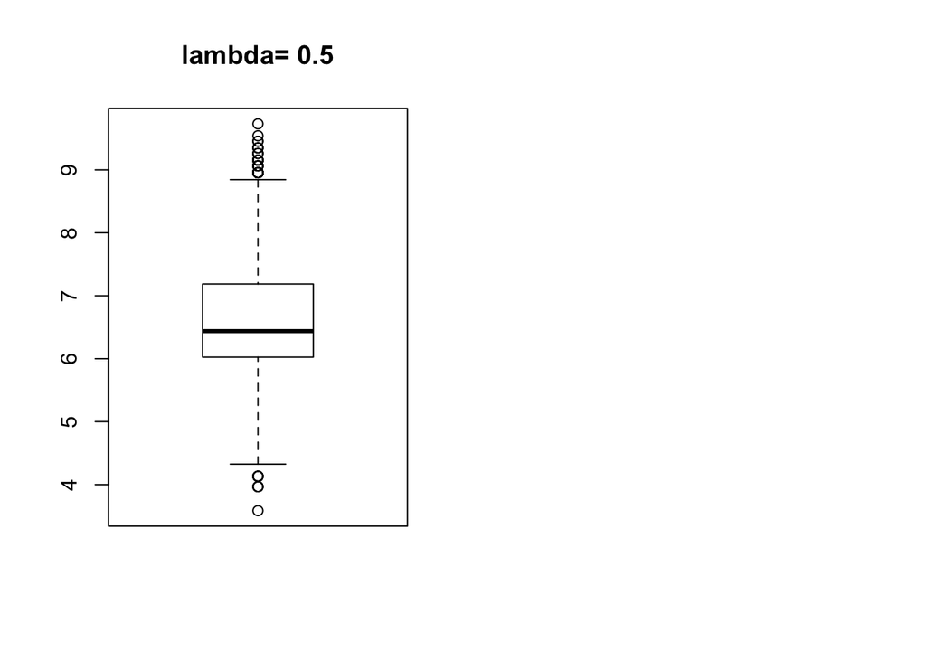

```r
par(Opar)
```

**lambda=-0.5 seems meet the biggest log-likelyhood and smallest Hinkley statistics, but from the box plots, lambda= 0.3 supports a more symmetric shape. Following transformation use a buit-in function to determine the lambda.**

```r
library('forecast')
BoxCox.lambda(DJF_max,method = 'loglik') # use log-likelihood method to determine lambda
```

```
## [1] -0.4
```

### b) do data transformation and check how close it is compared to normal distribution (lambda=-0.4)

```r
DJF_maxBC <- as.numeric(BoxCox(DJF_max,lambda = -0.4))
library('moments')
BCsk <- skewness(DJF_maxBC)
BCku <-kurtosis(DJF_maxBC)
print(paste('skweness after boxcox is ',BCsk))
```

```
## [1] "skweness after boxcox is  -0.00181841706794586"
```

```r
print(paste('kurtosis after boxcox is ',BCku))
```

```
## [1] "kurtosis after boxcox is  3.06362076930955"
```

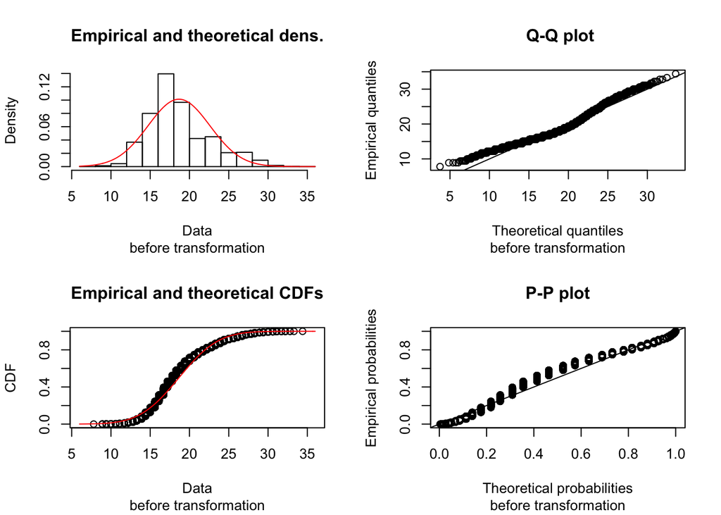

```r
library(fitdistrplus)
plot(fitdist(DJF_max,'norm',method='mle'), sub='before transformation')
```

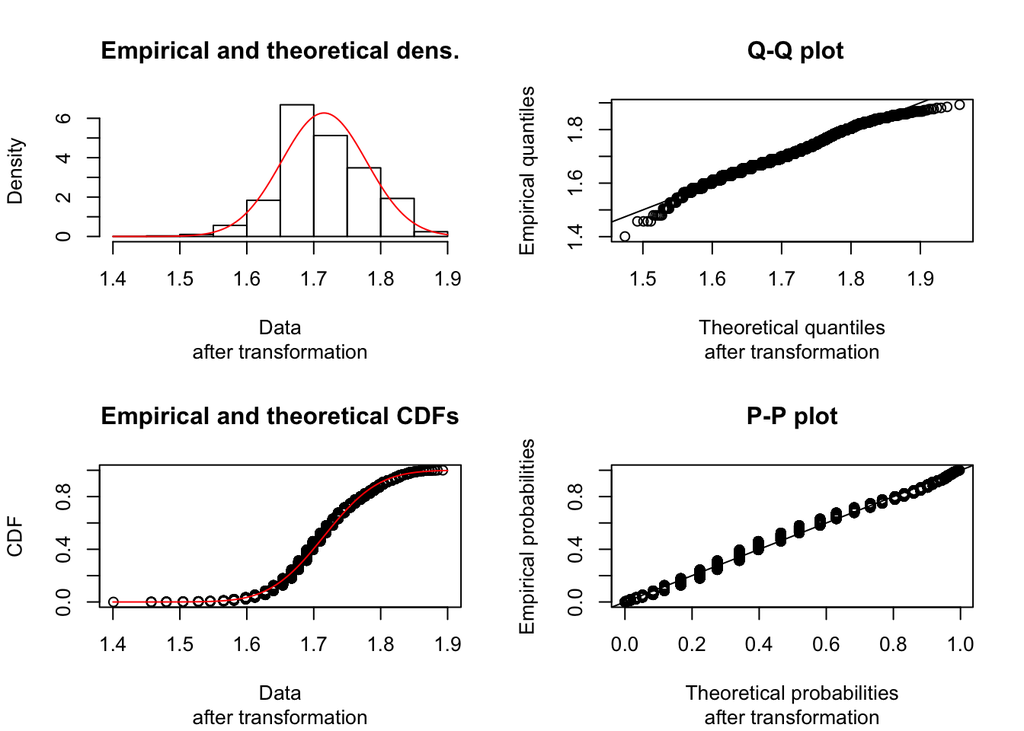

```r
plot(fitdist(DJF_maxBC,'norm',method = 'mle'),sub='after transformation')
```

**Skewness after transformation is more close to 0 and kurtosis after transformation is more close to 3.** **And density plot shows that transformation has more effect on the relatively large values, ‘twisting’ them into normal distribution shape. From the Q-Q plot, the deviation occurs when it comes to extrem values, which is also presented in the box plot.**

## problem5

### a)

**Thom’s approximation is writtecn as follow**

```r
## Thom's
lnDJF_max <- log(DJF_max)
D <- log(mean(DJF_max))-mean(lnDJF_max)
ALPHA <- (1+sqrt(1+4*D/3))/(4*D)
BETA <- mean(DJF_max)/ALPHA
print(paste('shape =',ALPHA,' sale =',BETA))
```

```
## [1] "shape = 23.7351447221839  sale = 0.786345668213412"
```

### b)

```r
## built-in function
library(MASS)
fitdistr(DJF_max,"gamma")
```

```
##       shape         rate
##   23.73507805    1.27170159
##  ( 0.40850385) ( 0.02211975)
```

```r
print(paste("shape calculated by Thom's approximation is",ALPHA))
```

```
## [1] "shape calculated by Thom's approximation is 23.7351447221839"
```

```r
print(paste("rate calculated by Thom's approximation is",1/BETA))
```

```
## [1] "rate calculated by Thom's approximation is 1.27170535862684"
```

### c)

$$D=ln(\bar x)-\frac{\sum_{i=1}^{\text{n}} ln(x_i)} {n}$$
$$x_{new}=10x$$
$$D_{new}=ln(10\bar x)-\frac{\sum_{i=1}^{n} ln(10x_i)} {n}$$
$$D_{new}=ln(10)+ln(\bar x)-\frac{nln(10)} {n}-\frac{\sum_{i=1}^{\text{n}} ln(x_i)} {n}=D$$

### d)

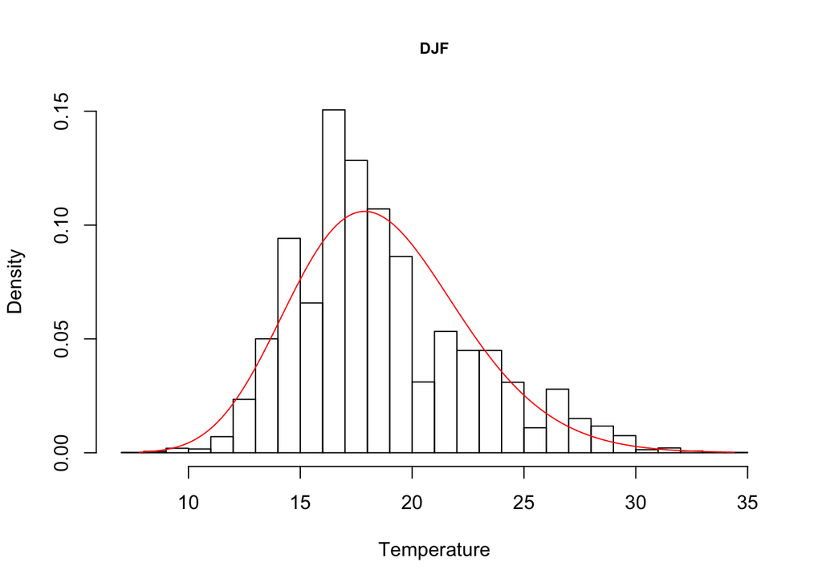

```r
hist(DJF_max,freq = F,xlab = 'Temperature',
     main='DJF',cex.main=0.8,breaks='Scott')
x1 <- seq(min(DJF_max),max(DJF_max),length=length(DJF_max))
y1 <- dgamma(x1,ALPHA,rate=1/BETA) #density
# how about accumulative density function? pgamma qgamma
lines(y1~x1,col='red')
```

### e)

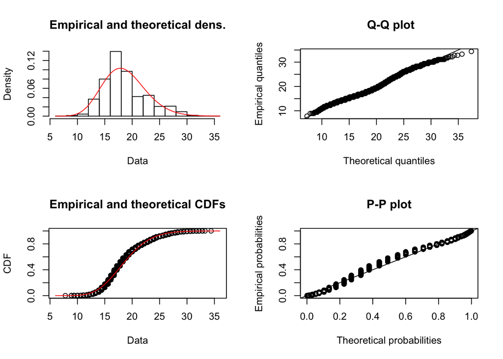

```r
library('fitdistrplus')
gammaFIT <- fitdist(DJF_max,'gamma',method='mme')
plot(gammaFIT)
```

**The Q-Q plot shows a better fit compared with the case where we first do box-cox transformation and fit the transformed data to normal distribution, while the density plot shows that original data clusters more around the mean than gamma distribution does.**

## problem 6

### a)

```r
JJA_maxbeyond <- JJA_max[JJA_max >= 33.3]
beyondFRACTION <- length(JJA_maxbeyond)/length(JJA_max)
print(paste('fraction of days that were as least 33.3 degree centigrade = ',beyondFRACTION))
```

```
## [1] "fraction of days that were as least 33.3 degree centigrade =  0.00570676031606672"
```

### b)

```r
Sn <- (33.3-mean(JJA_max))/sd(JJA_max) # standard normaly
print(paste('standard anomaly is',Sn))
```

```
## [1] "standard anomaly is 3.77431041196903"
```

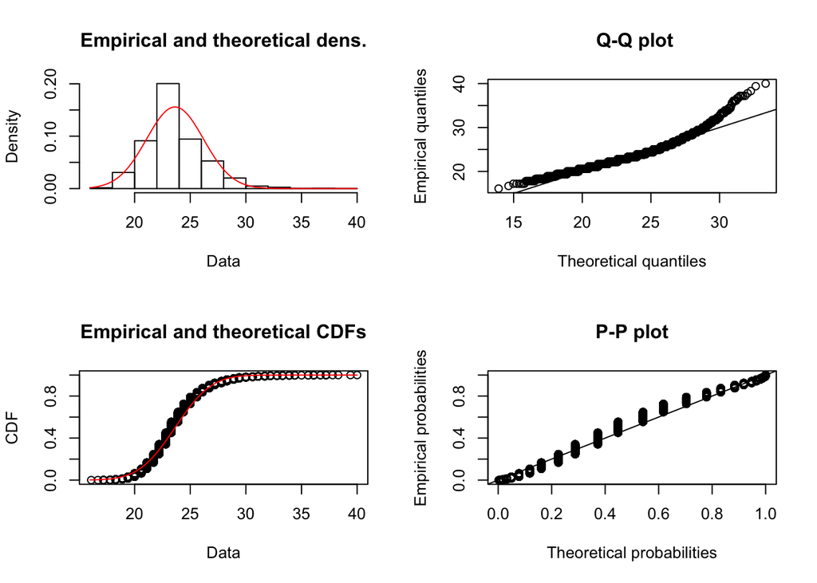

```r
normalDIST <- fitdist(JJA_max,'norm')
plot(normalDIST)
```

**The fit of normal distribution is not perfect, to fit the data into normal distribution, it is assumed that the data are mutually independent. Use acf function to test the correlation as below:**

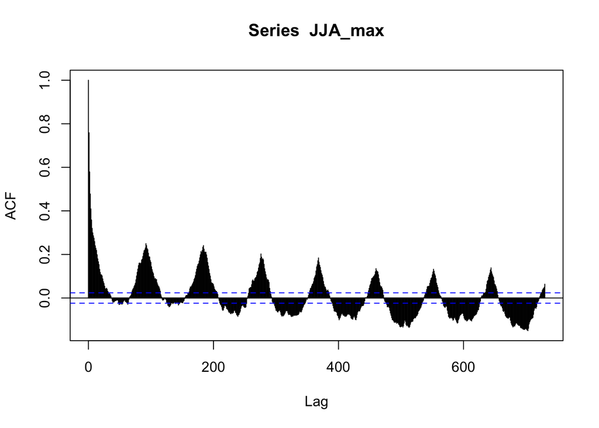

```r
acf(JJA_max,lag.max = 730)
```

**It is obvious that the data are not mutually independent.**

### d)

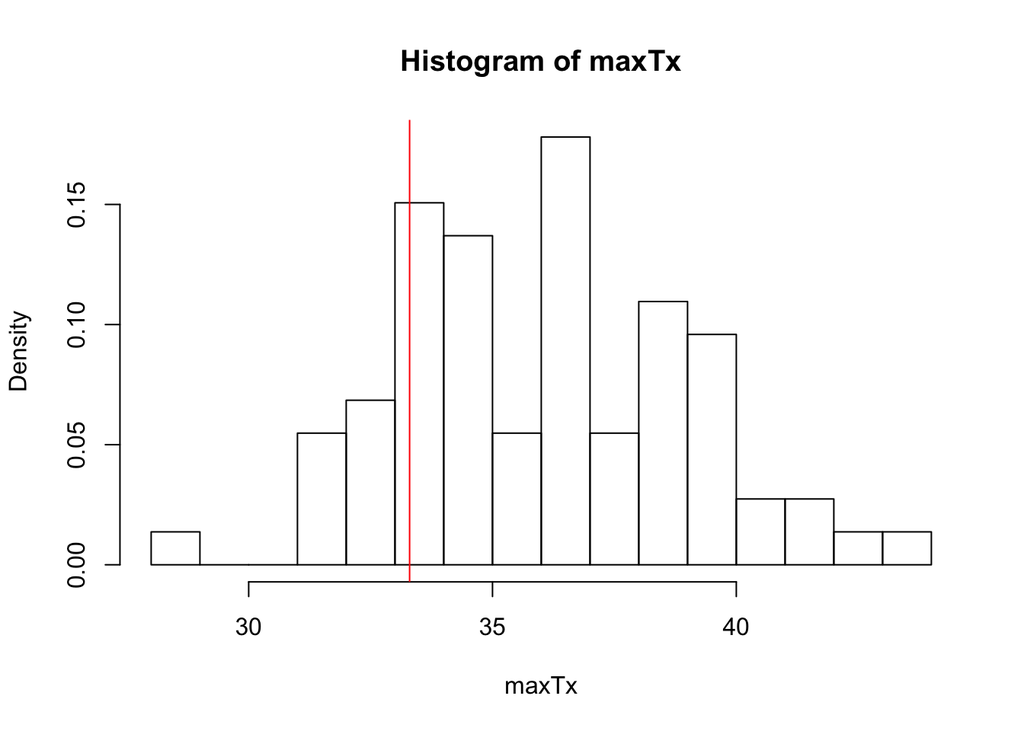

```r
## extract data for full years
FYvalue_max <- value_max[(interval1+2) : (interval1+1+Nyear_full*365)]

YSfactor <- c() # year seperator
for (i in (1:Nyear)){
  YSfactor <- c(YSfactor,rep(i,365))
}
YSfactor <- as.factor(YSfactor)
maxTx <- tapply(FYvalue_max, YSfactor, max)
maxTx <- as.numeric(maxTx)
date_3 <- as.Date('2013-8-13')
index1 <- as.numeric(difftime(date_3,date_1,units = 'days'))
Tx20130813 <- value_max[index1+1]
hist(maxTx,freq = F, breaks = 20)
abline(v=Tx20130813,col='red')
```

```r
fraction2 <- sum(maxTx>=33.3)/length(maxTx)
print(paste('fraction is',fraction2))
```

```
## [1] "fraction is 0.863013698630137"
```

**Although the probability of observing a temperature hotter than 33.3 degree centigrade during the whole time series is very small, but when only look at annual maximum temperature, the fraction of years has maximum tempareture greater than 33.3 is high, which means the occurance of temperature higher than 33.3 is not a ‘extreme’ phenomenon, on the contrary, it is quite normal due to seasonality(i.e the temperature data is seasonal and not independent)**